# 6. 模式识别

神经网络用于面部识别等应用，这些应用使用模式识别。

这种分类可以用感知器完成，感知器可用于将数据分为两部分。

感知器也称为线性二元分类器。

- 6.1 模式分类
- 6.2 编程实现
  - 6.2.1 生成随机数据
  - 6.2.2 计算正确值
  - 6.2.3 绘制正确值
  - 6.2.4 如何训练呢？

## 6.1 模式分类

想象一下空间中有一条直线（线性图），上面有散布的 (x, y) 点。

如何对直线上方和下方的点进行分类？

[figure not shown]

可以训练感知器识别线上/下的点，而无需了解直线的公式。

[figure not shown]

## 6.2 编程实现

我们可以使用一个简单的 Python 程序来实现上述问题，它将：

1. 创建一个简单的绘图仪
2. 创建 500 个随机 (x, y) 点
3. 显示 (x, y) 点
4. 创建直线函数：func(x)
5. 显示线
6. 计算正确答案
7. 显示正确答案

### 6.2.1 生成随机数据

创建任意数量的 xy 点。

让 x 值随机（介于 0 和最大值之间）。

让 y 值随机（介于 0 和最大值之间）。

在绘图仪中显示点并且定义线性函数 $y=1.2x+50$ 并以绿线绘制。

```
(0.0, 500.0)
```

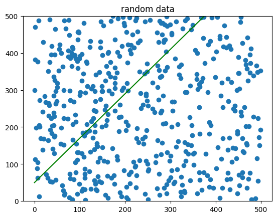

```python
import matplotlib.pyplot as plt
import numpy as np

data = np.random.randint(500, size=(2, 500))

def func(x):
    return 1.2*x + 50

plt.title('random data')
plt.scatter(data[0], data[1])

x = np.arange(0, 500, 1)
y = func(x)

plt.plot(x, y, color='green')
plt.ylim(0, 500)
```

### 6.2.2 计算正确值

根据线函数计算正确答案：

$y = x * 1.2 + 50$

如果 y 超过线，则期望答案为 1，如果 y 低于线，则期望答案为 0。

将期望答案存储在数组 (desired[]) 中。

```python
desired = []

for i in range(500):
    if(data[1][i] > func(data[0][i])):
        desired.append(1)
    else:
        desired.append(0)
```

### 6.2.3 绘制正确值

对于每个点，如果 desire[i] == 1，则显示一个黑点，否则显示一个蓝点。

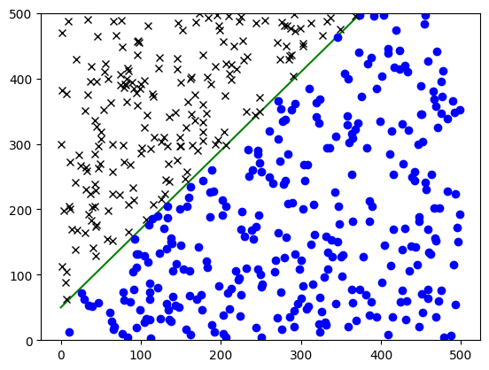

```python
plt.plot(x, y, color='green')
plt.ylim(0, 500)

for i in range(len(desired)):
    if desired[i] == 1:
        plt.plot(data[0][i],data[1][i],'x', color = "black")
    else:
        plt.plot(data[0][i],data[1][i],'o', color = "blue")
```

### 6.2.4 如何训练感知器

在下一章中，您将学习如何使用正确的答案来训练感知器以预测未知输入值所对应的输出值。